# Lab Assignment Five: Wide and Deep Network Architectures

Team members: Long Zhang,Qinyu Chen, Zhengwen Zhang

## Business understanding

Child poverty is the state of children living in poverty, the children may come from very poor families, or orphans living with very limited access to food, water, health care and educations. Child poverty is a serious social problem in the world.

In this lab, we are using a U.S census dataset from Kaggle, the goal of this study is to predict the child poverty rate by evaluating two different deep learning architectures and tuning hyper-parameters for each architecture. We choose this dataset because it has a large dataset for building a wide and deep network. It has a few different categorical features for the creation of the embeddings and cross-product embeddings.This model will be useful for Federal, State or city goverment agencies to take actions to prevent child poverty.

## 1. Preparation

1.1 Define and prepare your class variables. Use proper variable representations (int, float, one-hot, etc.). Use pre-processing methods (as needed) for dimensionality reduction, scaling, etc. Remove variables that are not needed/useful for the analysis. Describe the final dataset that is used for classification/regression (include a description of any newly formed variables you created).

```python
import pandas as pd
import matplotlib
import matplotlib.pyplot as plt
import warnings
import numpy as np
from sklearn.preprocessing import LabelEncoder
from sklearn.preprocessing import StandardScaler
from sklearn.preprocessing import OneHotEncoder
warnings.simplefilter('ignore', DeprecationWarning)
```

```python
#Load the data into memory and save it to a pandas data frame
df = pd.read_csv("/Users/chenqinyu/Desktop/acs2017_census_tract_data.csv")
#df = pd.read_csv("/Users/terrence/Desktop/acs2017_census_tract_data.csv")
#df = pd.read_csv(r"C:\Users\tony\Dropbox\smu\CSE7324\assignment\Lab4\acs2017_census_tract_data.csv")
```

Data source: https://www.kaggle.com/muonneutrino/us-census-demographic-data

```python
#remove missing values
df = df.dropna()
```

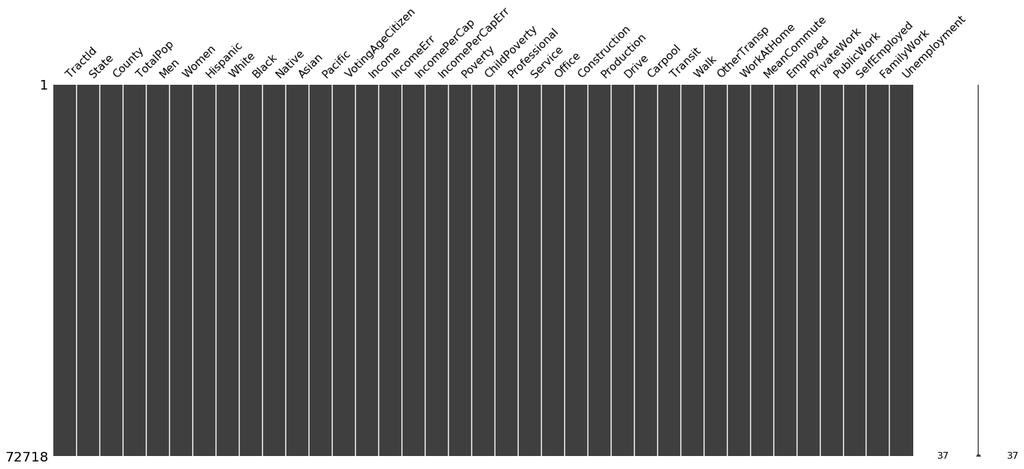

```python
import missingno as mn
mn.matrix(df)
```

no missing value is observed from the graph above, which is good.

```python
print(df.info())
```

```
<class 'pandas.core.frame.DataFrame'>
Int64Index: 72718 entries, 0 to 74000
Data columns (total 37 columns):
TractId             72718 non-null int64
State               72718 non-null object
County              72718 non-null object
TotalPop            72718 non-null int64
Men                 72718 non-null int64
Women               72718 non-null int64
Hispanic            72718 non-null float64
White               72718 non-null float64
Black               72718 non-null float64
Native              72718 non-null float64
Asian               72718 non-null float64
Pacific             72718 non-null float64
VotingAgeCitizen    72718 non-null int64
Income              72718 non-null float64
IncomeErr           72718 non-null float64
IncomePerCap        72718 non-null float64
IncomePerCapErr     72718 non-null float64
Poverty             72718 non-null float64
ChildPoverty        72718 non-null float64
Professional        72718 non-null float64
Service             72718 non-null float64
Office              72718 non-null float64
Construction        72718 non-null float64
Production          72718 non-null float64
Drive               72718 non-null float64
Carpool             72718 non-null float64
Transit             72718 non-null float64
Walk                72718 non-null float64
OtherTransp         72718 non-null float64
WorkAtHome          72718 non-null float64
MeanCommute         72718 non-null float64
Employed            72718 non-null int64
PrivateWork         72718 non-null float64
PublicWork          72718 non-null float64
SelfEmployed        72718 non-null float64
FamilyWork          72718 non-null float64
Unemployment        72718 non-null float64
dtypes: float64(29), int64(6), object(2)
memory usage: 21.1+ MB
None
```

```python
df.head()
```

|  | TractId | State | County | TotalPop | Men | Women | Hispanic | White | Black | Native | ... | Walk | OtherTransp | WorkAtHome | MeanCommute | Employed | PrivateWork | PublicWork | SelfEmployed | FamilyWork | Unemployment |
| --- | --- | --- | --- | --- | --- | --- | --- | --- | --- | --- | --- | --- | --- | --- | --- | --- | --- | --- | --- | --- | --- |
| 0 | 1001020100 | Alabama | Autauga County | 1845 | 899 | 946 | 2.4 | 86.3 | 5.2 | 0.0 | ... | 0.5 | 0.0 | 2.1 | 24.5 | 881 | 74.2 | 21.2 | 4.5 | 0.0 | 4.6 |
| 1 | 1001020200 | Alabama | Autauga County | 2172 | 1167 | 1005 | 1.1 | 41.6 | 54.5 | 0.0 | ... | 0.0 | 0.5 | 0.0 | 22.2 | 852 | 75.9 | 15.0 | 9.0 | 0.0 | 3.4 |
| 2 | 1001020300 | Alabama | Autauga County | 3385 | 1533 | 1852 | 8.0 | 61.4 | 26.5 | 0.6 | ... | 1.0 | 0.8 | 1.5 | 23.1 | 1482 | 73.3 | 21.1 | 4.8 | 0.7 | 4.7 |
| 3 | 1001020400 | Alabama | Autauga County | 4267 | 2001 | 2266 | 9.6 | 80.3 | 7.1 | 0.5 | ... | 1.5 | 2.9 | 2.1 | 25.9 | 1849 | 75.8 | 19.7 | 4.5 | 0.0 | 6.1 |
| 4 | 1001020500 | Alabama | Autauga County | 9965 | 5054 | 4911 | 0.9 | 77.5 | 16.4 | 0.0 | ... | 0.8 | 0.3 | 0.7 | 21.0 | 4787 | 71.4 | 24.1 | 4.5 | 0.0 | 2.3 |

5 rows × 37 columns

From the information of the raw data, we could tell that the there are basically only two categorical features: one is State, another one is County, so which is not very applicable for wide and deep network model, So we make two more categorical features--they are Transit and unemployment, the reason why we would choose these two is our target prediction is ChildPoverty, and based on both our common sense and fact that poor people would love to choose pubilc. transit to be their transportation tool, and unemployment is also crucial element to poverty, the higher the unemployment rate, the highr the poverty rate.

```python
df['Transit'].describe()
```

```
count    72718.000000
mean         5.370585
std         11.626060
min          0.000000
25%          0.000000
50%          1.000000
75%          4.600000
max         90.800000
Name: Transit, dtype: float64
```

```python
df['Transit']= pd.cut(df.Transit, [0,1,4.6,90.8], labels=['rare_use', 'normal_use', "much_use"])
```

```python
df['Unemployment'].describe()
```

```
count    72718.000000
mean         7.224917
std          5.099419
min          0.000000
25%          3.900000
50%          6.000000
75%          9.000000
max         62.800000
Name: Unemployment, dtype: float64
```

```python
df['Unemployment']= pd.cut(df.Unemployment, [0,3.9,6,9,62.8], labels=['very_less', 'less', "normal","much"])
```

```python
df['ChildPoverty'].describe()
```

```
count    72718.000000
mean        21.148476
std         18.572714
min          0.000000
25%          6.200000
50%         16.300000
75%         31.600000
max        100.000000
Name: ChildPoverty, dtype: float64
```

```python
df['ChildPoverty'] = pd.cut(df.ChildPoverty, [-1,6.31,16.31,31.61,100], labels=['0','1','2','3'])
```

```python
df.head()
```

|  | TractId | State | County | TotalPop | Men | Women | Hispanic | White | Black | Native | ... | Walk | OtherTransp | WorkAtHome | MeanCommute | Employed | PrivateWork | PublicWork | SelfEmployed | FamilyWork | Unemployment |
| --- | --- | --- | --- | --- | --- | --- | --- | --- | --- | --- | --- | --- | --- | --- | --- | --- | --- | --- | --- | --- | --- |
| 0 | 1001020100 | Alabama | Autauga County | 1845 | 899 | 946 | 2.4 | 86.3 | 5.2 | 0.0 | ... | 0.5 | 0.0 | 2.1 | 24.5 | 881 | 74.2 | 21.2 | 4.5 | 0.0 | less |
| 1 | 1001020200 | Alabama | Autauga County | 2172 | 1167 | 1005 | 1.1 | 41.6 | 54.5 | 0.0 | ... | 0.0 | 0.5 | 0.0 | 22.2 | 852 | 75.9 | 15.0 | 9.0 | 0.0 | very_less |
| 2 | 1001020300 | Alabama | Autauga County | 3385 | 1533 | 1852 | 8.0 | 61.4 | 26.5 | 0.6 | ... | 1.0 | 0.8 | 1.5 | 23.1 | 1482 | 73.3 | 21.1 | 4.8 | 0.7 | less |
| 3 | 1001020400 | Alabama | Autauga County | 4267 | 2001 | 2266 | 9.6 | 80.3 | 7.1 | 0.5 | ... | 1.5 | 2.9 | 2.1 | 25.9 | 1849 | 75.8 | 19.7 | 4.5 | 0.0 | normal |
| 4 | 1001020500 | Alabama | Autauga County | 9965 | 5054 | 4911 | 0.9 | 77.5 | 16.4 | 0.0 | ... | 0.8 | 0.3 | 0.7 | 21.0 | 4787 | 71.4 | 24.1 | 4.5 | 0.0 | very_less |

5 rows × 37 columns

```python
df=df.drop(['TractId','Men', 'Women','Hispanic','White','Black','Native','Asian','Pacific','VotingAgeCitizen','Carpool','OtherTransp',
         'WorkAtHome','MeanCommute','PrivateWork','PublicWork',
        'SelfEmployed','FamilyWork'], axis=1)
```

```python
print(df.info())
```

```
<class 'pandas.core.frame.DataFrame'>
Int64Index: 72718 entries, 0 to 74000
Data columns (total 19 columns):
State              72718 non-null object
County             72718 non-null object
TotalPop           72718 non-null int64
Income             72718 non-null float64
IncomeErr          72718 non-null float64
IncomePerCap       72718 non-null float64
IncomePerCapErr    72718 non-null float64
Poverty            72718 non-null float64
ChildPoverty       72718 non-null category
Professional       72718 non-null float64
Service            72718 non-null float64
Office             72718 non-null float64
Construction       72718 non-null float64
Production         72718 non-null float64
Drive              72718 non-null float64
Transit            49986 non-null category
Walk               72718 non-null float64
Employed           72718 non-null int64
Unemployment       72483 non-null category
dtypes: category(3), float64(12), int64(2), object(2)
memory usage: 9.6+ MB
None
```

### 1.2 Identify groups of features in your data that should be combined into cross-product features. Provide justification for why these features should be crossed (or why some features should not be crossed).

```python
df['State'] = df['State'].astype(str)
df['County'] = df['County'].astype(str)
df['Transit'] = df['Transit'].astype(str)
df['Unemployment'] = df['Unemployment'].astype(str)
```

```python
# define objects that can encode each variable as integer
encoders = dict()
categorical_headers = ['State','County','Transit','Unemployment']

# train all encoders (special case the target 'income')
for col in categorical_headers+['ChildPoverty']:
    if col=="ChildPoverty":
        tmp = LabelEncoder()
        df[col] = tmp.fit_transform(df[col])
    else:
        # integer encoded variables
        encoders[col] = LabelEncoder() # save the encoder
        df[col+'_int'] = encoders[col].fit_transform(df[col])





# scale the numeric, continuous variables
numeric_headers = ["TotalPop", "Income", "IncomeErr", "IncomePerCap", "IncomePerCapErr", "Poverty",
                   'Professional','Service','Office','Construction','Production','Drive','Walk','Employed']

for col in numeric_headers:
    df[col] = df[col].astype(np.float)

    ss = StandardScaler()
    df[col] = ss.fit_transform(df[col].values.reshape(-1, 1))

df.head()
```

|  | State | County | TotalPop | Income | IncomeErr | IncomePerCap | IncomePerCapErr | Poverty | ChildPoverty | Professional | ... | Production | Drive | Transit | Walk | Employed | Unemployment | State_int | County_int | Transit_int | Unemployment_int |
| --- | --- | --- | --- | --- | --- | --- | --- | --- | --- | --- | --- | --- | --- | --- | --- | --- | --- | --- | --- | --- | --- |
| 0 | Alabama | Autauga County | -1.186432 | 0.219791 | 0.795781 | 0.148406 | 0.683478 | -0.430197 | 2 | 0.195907 | ... | -0.068794 | 1.224511 | nan | -0.461123 | -1.071607 | less | 0 | 89 | 1 | 0 |
| 1 | Alabama | Autauga County | -1.037128 | -0.650031 | -0.959466 | -0.736597 | -0.600713 | 0.511184 | 3 | -0.336054 | ... | 0.326335 | 0.977191 | nan | -0.556169 | -1.097497 | very_less | 0 | 89 | 1 | 4 |
| 2 | Alabama | Autauga County | -0.483289 | -0.469145 | -0.031756 | -0.595219 | -0.564270 | -0.108357 | 2 | -0.508942 | ... | -0.437581 | 0.830136 | nan | -0.366077 | -0.535049 | less | 0 | 89 | 1 | 0 |
| 3 | Alabama | Autauga County | -0.080581 | -0.171251 | -0.869588 | -0.164015 | -0.354306 | -1.106060 | 0 | -0.435797 | ... | 0.866345 | 0.429078 | nan | -0.271030 | -0.207400 | normal | 0 | 89 | 1 | 3 |
| 4 | Alabama | Autauga County | 2.521046 | 0.230180 | 0.773556 | 0.393735 | 2.158575 | -0.309507 | 2 | 0.880807 | ... | 0.062916 | 0.736556 | nan | -0.404095 | 2.415575 | very_less | 0 | 89 | 1 | 4 |

5 rows × 23 columns

```python
df.info()
```

```
<class 'pandas.core.frame.DataFrame'>
Int64Index: 72718 entries, 0 to 74000
Data columns (total 23 columns):
State               72718 non-null object
County              72718 non-null object
TotalPop            72718 non-null float64
Income              72718 non-null float64
IncomeErr           72718 non-null float64
IncomePerCap        72718 non-null float64
IncomePerCapErr     72718 non-null float64
Poverty             72718 non-null float64
ChildPoverty        72718 non-null int64
Professional        72718 non-null float64
Service             72718 non-null float64
Office              72718 non-null float64
Construction        72718 non-null float64
Production          72718 non-null float64
Drive               72718 non-null float64
Transit             72718 non-null object
Walk                72718 non-null float64
Employed            72718 non-null float64
Unemployment        72718 non-null object
State_int           72718 non-null int64
County_int          72718 non-null int64
Transit_int         72718 non-null int64
Unemployment_int    72718 non-null int64
dtypes: float64(14), int64(5), object(4)
memory usage: 13.3+ MB
```

```python
order = ['State','County','State_int','Transit','Unemployment' ,'County_int', 'Transit_int', 'Unemployment_int', 'TotalPop', 'Income',
         'IncomeErr', 'IncomePerCap', 'IncomePerCapErr', 'Poverty', 'Professional',
         'Service', 'Office', 'Construction', 'Production', 'Drive', 'Walk', 'Employed','ChildPoverty']
```

```python
df = df.reindex(columns = order)
```

```python
df.info()
```

```
<class 'pandas.core.frame.DataFrame'>
Int64Index: 72718 entries, 0 to 74000
Data columns (total 23 columns):
State               72718 non-null object
County              72718 non-null object
State_int           72718 non-null int64
Transit             72718 non-null object
Unemployment        72718 non-null object
County_int          72718 non-null int64
Transit_int         72718 non-null int64
Unemployment_int    72718 non-null int64
TotalPop            72718 non-null float64
Income              72718 non-null float64
IncomeErr           72718 non-null float64
IncomePerCap        72718 non-null float64
IncomePerCapErr     72718 non-null float64
Poverty             72718 non-null float64
Professional        72718 non-null float64
Service             72718 non-null float64
Office              72718 non-null float64
Construction        72718 non-null float64
Production          72718 non-null float64
Drive               72718 non-null float64
Walk                72718 non-null float64
Employed            72718 non-null float64
ChildPoverty        72718 non-null int64
dtypes: float64(14), int64(5), object(4)
memory usage: 13.3+ MB
```

```python
# let's start as simply as possible, without any feature preprocessing
categorical_headers_ints = [x+'_int' for x in categorical_headers]
feature_columns = categorical_headers_ints+numeric_headers
print(feature_columns)
```

```
['State_int', 'County_int', 'Transit_int', 'Unemployment_int', 'TotalPop', 'Income', 'IncomeErr', 'IncomePerCap', 'IncomePerCapErr', 'Poverty', 'Professional', 'Service', 'Office', 'Construction', 'Production', 'Drive', 'Walk', 'Employed']
```

```python
from sklearn.model_selection import train_test_split
X_df_train, X_df_test = train_test_split(df, test_size=0.2, random_state=10, stratify=df['ChildPoverty'])
```

```python
y_train = X_df_train['ChildPoverty'].values.astype(int)
y_test = X_df_test['ChildPoverty'].values.astype(int)
```

```python
X_train_num =  X_df_train[numeric_headers].values
X_test_num = X_df_test[numeric_headers].values
```

```python
X_train =  X_df_train[numeric_headers].astype(int)
X_test = X_df_test[numeric_headers].astype(int)
```

Like lab4, our research target is still ChildPoverty, and we divided 4 parts, so it becomes a multi classification.  
Our feature is :'State_int', 'County_int', 'Transit_int', 'Unemployment_int', 'TotalPop', 'Income', 'IncomeErr', 'IncomePerCap', 'IncomePerCapErr', 'Poverty', 'Professional', 'Service', 'Office', 'Construction', 'Production', 'Drive', 'Walk', 'Employed'.